# Report for PS 1

Jack Xie

# Dynamic properties of financial return series

Please see below for some summary statistics of the international stock indexes.

```r
# generate log returns
lret = apply(log(index_d), 2, diff)

# summarize data
descr <- describe(lret)
descr <- descr[, c("n", "mean", "sd", "median", "min", "max", "skew", "kurtosis")]

kable(descr)
```

|  | n | mean | sd | median | min | max | skew | kurtosis |
| --- | --- | --- | --- | --- | --- | --- | --- | --- |
| DAXINDX | 3127 | 0.0003493 | 0.0123305 | 0.0002581 | -0.1370990 | 0.0728754 | -0.9460104 | 12.060788 |
| FRCAC40 | 2734 | 0.0002576 | 0.0119880 | 0.0000000 | -0.1013757 | 0.0822544 | -0.5290250 | 7.555638 |
| FTSE100 | 3127 | 0.0004102 | 0.0091921 | 0.0002738 | -0.1302860 | 0.0759697 | -1.5891074 | 24.399043 |
| HNGKNGI | 3127 | 0.0005713 | 0.0169331 | 0.0002220 | -0.4054220 | 0.1724710 | -5.0014896 | 116.202714 |
| NIKKEI | 3127 | 0.0000499 | 0.0135719 | 0.0000000 | -0.1613542 | 0.1243033 | -0.2127685 | 11.793004 |
| SNGALLS | 3127 | 0.0001921 | 0.0101020 | 0.0000000 | -0.0940305 | 0.1431299 | -0.2470296 | 25.137475 |
| SPCOMP | 3127 | 0.0004885 | 0.0099323 | 0.0003843 | -0.2283303 | 0.0870888 | -4.2977428 | 96.648080 |

## Autocorrelation of international stock indexes

This answers Part 1BQ1.

### ACF and PACF Background

For each lag period $k$, the **ACF** plot shows the autocorrelation of $y_t$ and $y_{t+k}$. The significance of the ACF coefficients reveals whether $y_t$ exhibits behavior of an **autoregressive (AR)** process.

For each lag period $k$, the **PACF** plot shows the the autocorrelation of series $z_t$ and $z_{t+k}$ with the linear dependence of $z_t$ on $z_{t+1}, z_{t+2}, …, z_{t+k}$ removed. The significance of the PACF coefficients tell reveals whether $y_t$ exhibits behavior of a **moving average (MA)** process.

### ACF and PAC Results

**HNGKNGI** and **SNGALLS** exhibit tailing off in the ACF plot. Then these series may be modeled with an AR model. Therefore, these series may be autocorrelated.

**FTSE100** exhibits some tailing off in the ACF and PACF plots, and may be modeled with an ARMA model. Therefore, this index may be autocorrelated.

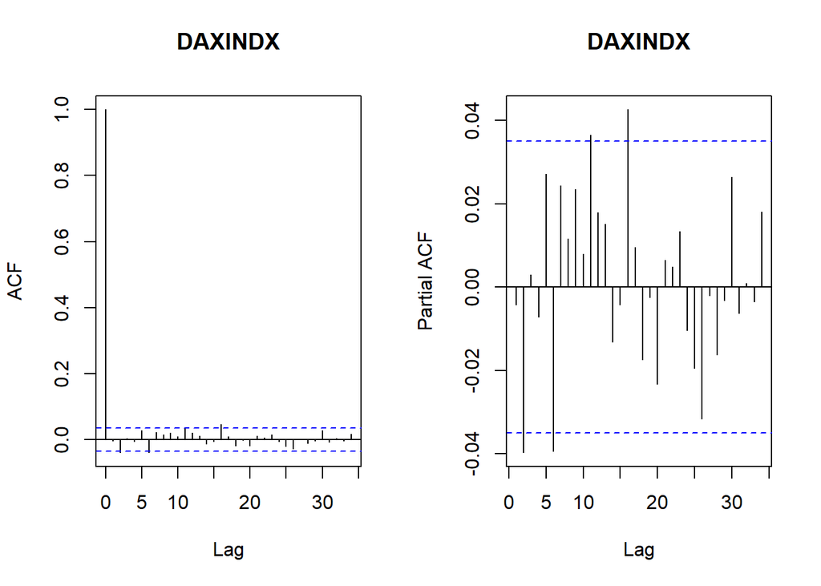

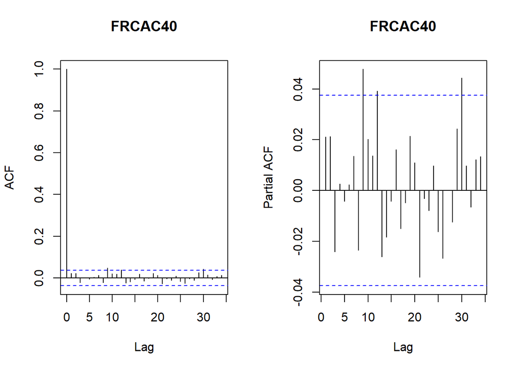

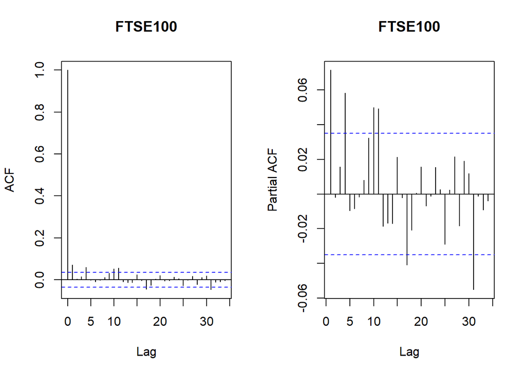

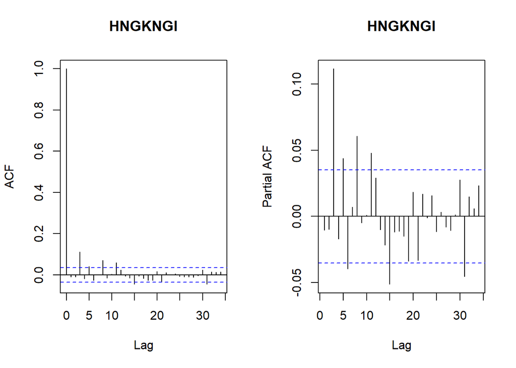

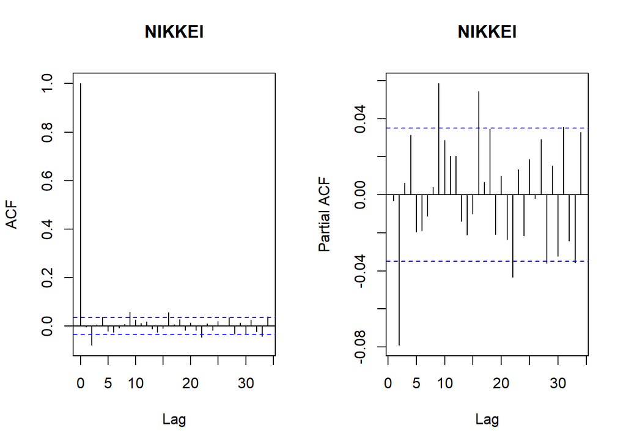

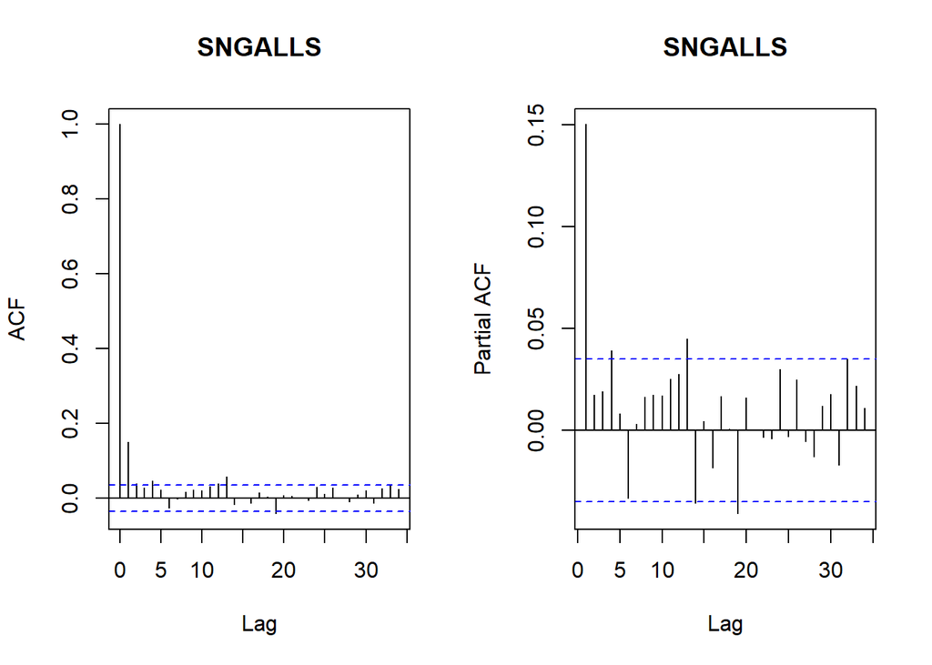

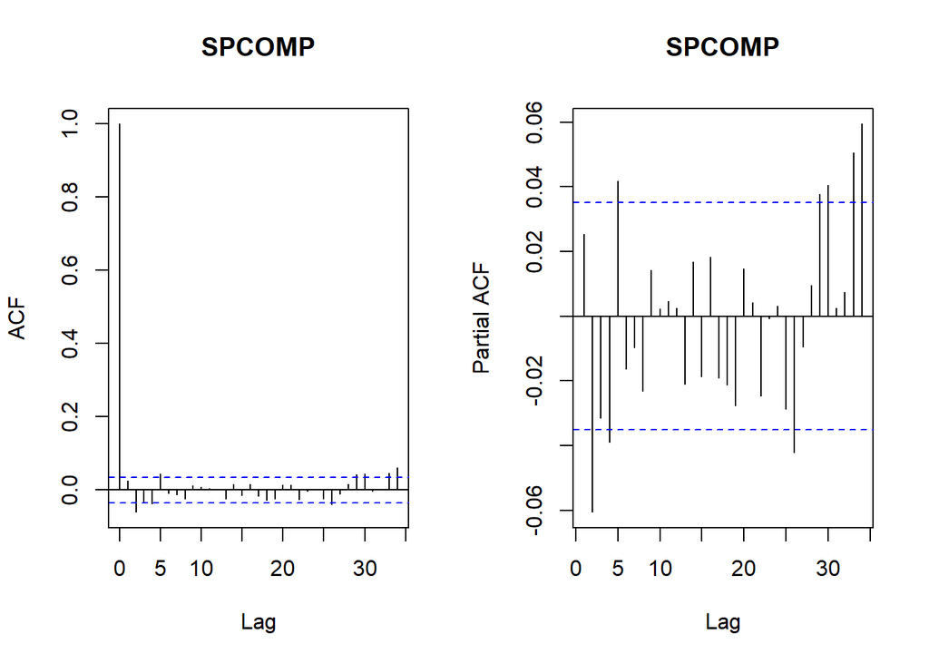

```r
acf_tabs <- function(data, lag.max=20, plot=T){

  # create tables for ACF and PACF values
  acf_tab <- matrix(nrow=ncol(data), ncol=lag.max,
                    dimnames=list(index=colnames(data),
                                  lag=1:lag.max
                    )
  )
  pacf_tab <- matrix(nrow=ncol(data), ncol=lag.max,
                     dimnames=list(index=colnames(data),
                                   lag=1:lag.max)
  )

  for (c in colnames(data)){

    # data for each column removing na
    x <- data[!is.na(data[,c]), c]


    if (plot){
    # two columns for ACF and PACF
    par(mfcol=c(1, 2))
    }

    # plot ACf and PACF
    acf_val <- acf(x, main=c, plot=plot)
    pacf_val <- pacf(x, main=c, plot=plot)

    # save coefficients
    acf_tab[c, ] <- acf_val$acf[2:(lag.max+1)]
    pacf_tab[c, ] <- pacf_val$acf[1:lag.max]

  }

  return(list(acf=acf_tab, pacf=pacf_tab))

}

tabs = acf_tabs(lret)
```

```r
# xtable(t(tabs$acf))
# xtable(t(tabs$pacf))

kable(t(tabs$acf))
```

| DAXINDX | FRCAC40 | FTSE100 | HNGKNGI | NIKKEI | SNGALLS | SPCOMP |
| --- | --- | --- | --- | --- | --- | --- |
| -0.0041690 | 0.0210953 | 0.0714735 | -0.0101455 | -0.0032685 | 0.1501179 | 0.0253631 |
| -0.0397326 | 0.0216883 | 0.0031939 | -0.0094710 | -0.0790048 | 0.0394888 | -0.0598867 |
| 0.0033352 | -0.0231501 | 0.0156611 | 0.1115451 | 0.0066136 | 0.0271717 | -0.0345152 |
| -0.0056433 | 0.0021480 | 0.0602863 | -0.0188219 | 0.0374276 | 0.0455496 | -0.0368385 |
| 0.0268536 | -0.0051456 | -0.0009952 | 0.0414910 | -0.0206824 | 0.0215329 | 0.0436715 |
| -0.0390162 | 0.0027550 | -0.0088935 | -0.0267421 | -0.0239652 | -0.0254051 | -0.0084126 |
| 0.0223498 | 0.0133394 | -0.0013915 | 0.0024238 | -0.0075388 | -0.0030570 | -0.0129679 |
| 0.0148685 | -0.0224829 | 0.0110464 | 0.0701938 | 0.0080983 | 0.0166078 | -0.0232467 |
| 0.0207366 | 0.0471461 | 0.0326406 | -0.0145830 | 0.0576936 | 0.0219925 | 0.0116345 |
| 0.0081635 | 0.0206170 | 0.0528963 | 0.0034137 | 0.0260064 | 0.0208487 | 0.0091067 |
| 0.0321074 | 0.0177055 | 0.0560362 | 0.0590351 | 0.0114211 | 0.0306018 | 0.0045572 |
| 0.0196751 | 0.0380681 | -0.0091360 | 0.0246921 | 0.0177529 | 0.0386792 | 0.0023406 |
| 0.0106132 | -0.0239907 | -0.0134494 | -0.0057443 | -0.0119242 | 0.0573594 | -0.0241892 |
| -0.0138824 | -0.0188067 | -0.0119718 | -0.0148002 | -0.0240512 | -0.0161792 | 0.0161120 |
| -0.0063222 | -0.0083453 | 0.0237129 | -0.0439948 | -0.0100535 | 0.0020733 | -0.0147922 |
| 0.0458193 | 0.0181896 | -0.0029311 | -0.0052274 | 0.0555227 | -0.0139530 | 0.0167901 |
| 0.0085564 | -0.0157534 | -0.0435591 | -0.0161800 | 0.0050944 | 0.0146811 | -0.0156928 |
| -0.0192475 | -0.0022260 | -0.0255043 | -0.0252456 | 0.0272970 | 0.0029925 | -0.0265734 |
| -0.0021391 | 0.0217356 | 0.0046421 | -0.0263395 | -0.0169151 | -0.0414476 | -0.0241845 |
| -0.0188749 | 0.0118975 | 0.0199851 | 0.0157719 | 0.0134593 | 0.0064272 | 0.0141869 |

```r
kable(t(tabs$pacf))
```

| DAXINDX | FRCAC40 | FTSE100 | HNGKNGI | NIKKEI | SNGALLS | SPCOMP |
| --- | --- | --- | --- | --- | --- | --- |
| -0.0041690 | 0.0210953 | 0.0714735 | -0.0101455 | -0.0032685 | 0.1501179 | 0.0253631 |
| -0.0397507 | 0.0212528 | -0.0019243 | -0.0095749 | -0.0790164 | 0.0173443 | -0.0605690 |
| 0.0030020 | -0.0240678 | 0.0156499 | 0.1113726 | 0.0061150 | 0.0191808 | -0.0315038 |
| -0.0072072 | 0.0026777 | 0.0583681 | -0.0169620 | 0.0314245 | 0.0390023 | -0.0389598 |
| 0.0270964 | -0.0042286 | -0.0095058 | 0.0437554 | -0.0196044 | 0.0083031 | 0.0418500 |
| -0.0394118 | 0.0022941 | -0.0084190 | -0.0394678 | -0.0189227 | -0.0331011 | -0.0163181 |
| 0.0243748 | 0.0135712 | -0.0017659 | 0.0071063 | -0.0112605 | 0.0032037 | -0.0096654 |
| 0.0116410 | -0.0234308 | 0.0079407 | 0.0604877 | 0.0038695 | 0.0163143 | -0.0231703 |
| 0.0234846 | 0.0477886 | 0.0324164 | -0.0048931 | 0.0583806 | 0.0174467 | 0.0141290 |
| 0.0078972 | 0.0202160 | 0.0498549 | 0.0009612 | 0.0287400 | 0.0169247 | 0.0021869 |
| 0.0365082 | 0.0136916 | 0.0493352 | 0.0478240 | 0.0203455 | 0.0253208 | 0.0046542 |
| 0.0178439 | 0.0392181 | -0.0185544 | 0.0289866 | 0.0203817 | 0.0275851 | 0.0025170 |
| 0.0150676 | -0.0260771 | -0.0167910 | -0.0100349 | -0.0138678 | 0.0448873 | -0.0209189 |
| -0.0132318 | -0.0183722 | -0.0170811 | -0.0215625 | -0.0209723 | -0.0355332 | 0.0166838 |
| -0.0042994 | -0.0041990 | 0.0212754 | -0.0511265 | -0.0099733 | 0.0044149 | -0.0187047 |
| 0.0426343 | 0.0160593 | -0.0021360 | -0.0116616 | 0.0542573 | -0.0183124 | 0.0182777 |
| 0.0094886 | -0.0150161 | -0.0408258 | -0.0112166 | 0.0066357 | 0.0165839 | -0.0191720 |
| -0.0174643 | -0.0047620 | -0.0208949 | -0.0147817 | 0.0346132 | 0.0008245 | -0.0212183 |
| -0.0024585 | 0.0213762 | 0.0005863 | -0.0336340 | -0.0208407 | -0.0407689 | -0.0275848 |
| -0.0233473 | 0.0110189 | 0.0156907 | 0.0182858 | 0.0097173 | 0.0160491 | 0.0145995 |

## Ljung-Box Test

This part answers Part 1BQ2.

The Ljung-Box statistic is given by
$$Q_{LB}(k) = T(T+2) \sum_{j=1}^k \frac{\hat \rho^2}{T-j}
\sim \chi^2(k-p)$$

which tests the null hypothesis of no autocorrelation,

$$\begin{align}
H_0 &: \rho_1 = \rho_2 = ... = \rho_k = 0. \\
H_1 &: \exists j \in \{1, 2, ..., k\}, \; \rho_j \ne 0.
\end{align}$$

```r
# Ljung-Box test function
LB <- function(data, lag, p){

  # time periods
  T <- length(data)

  # get ACF coeffs
  rho = acf(data, lag.max=lag, plot=F)$acf

  # remove 0th lag coeffs then square
  rho_sq = rho[2:(lag+1)]**2

  # test statistic
  Q = T * (T+2) * sum(rho_sq / (T-1:lag))

  # return test and p-value
  return(list(test=Q, pval=1-pchisq(Q, df=lag-p)))
}


# lag periods to test
lags <- c(10, 50, 100)

# degrees of freedom df = lag - p
# p is number of parameters estimated
p <- 0

# table of LB test statistics
LB_tests <- matrix(nrow=length(lags), ncol=ncol(lret),
                  dimnames=list(lag=lags, index=colnames(lret))
                  )

# table of Chi-square test p-values
LB_pvals <- matrix(nrow=length(lags), ncol=ncol(lret),
                   dimnames=list(lag=lags, index=colnames(lret))
                   )

# run Ljung-Box tests
for (c in colnames(lret)){

  for (i in 1:3){

    # remove na from data
    x <- lret[!is.na(lret[,c]), c]
    LB_res <- LB(x, lag=lags[i], p)

    # significance level stars
    pval <- signif(LB_res$pval, 3)
    for (qt in c(0.1, 0.05, 0.01)){
      if (LB_res$pval < qt){
        pval <- paste(pval,'*', sep='')
      }
    }

    # save test stat and pvals
    LB_tests[i, c] <- LB_res$test
    LB_pvals[i, c] <- pval

  }
}


comment <- paste('This table presents p-values of',
                 'Ljung-Box tests of no autocorrelation.',
                 'Significance levels:',
                 '\\* p-value < 0.1,',
                 '\\** p-value < 0.5,',
                 '\\*** p-value <0.01.')

kable(LB_pvals, caption=comment)
```

This table presents p-values of Ljung-Box tests of no autocorrelation. Significance levels: * p-value < 0.1, ** p-value < 0.5, *** p-value <0.01.

|  | DAXINDX | FRCAC40 | FTSE100 | HNGKNGI | NIKKEI | SNGALLS | SPCOMP |
| --- | --- | --- | --- | --- | --- | --- | --- |
| 10 | 0.1 | 0.211 | 1.16e-05*** | 5.05e-10*** | 1.57e-05*** | 2.66e-15*** | 0.000756*** |
| 50 | 0.04** | 0.303 | 2.21e-06*** | 1.68e-09*** | 6.38e-08*** | 2.3e-13*** | 1.26e-07*** |
| 100 | 0.0969* | 0.583 | 0.000765*** | 1.98e-06*** | 5.18e-05*** | 6.47e-09*** | 7.55e-08*** |

```r
# LB_tests <- list(LB_tests)
# attr(LB_tests, "message") <- c(
#                   'This table presents p-values of Ljung-Box tests of no autocorrelation.',
#                  'Significance levels:',
#                  '* p-value < 0.1,',
#                  '** p-value < 0.5,',
#                  '*** p-value <0.01.'
#                  )
#
# print(
#  xtable(LB_pvals, caption="Table of chi-square p-values")
#       , caption.placement = "top"
#       , sanitize.text.function = identity
#       )
```

From the p-value of the test results, for all lag orders $k \in \{10, 50, 100\}$ we can reject the null of no autocorrelation for the **FTSE100, HNGKNGI, NIKKEI, SNGALLS,** and **SPCOMP** at less than the 1% quantile level of the Chi-squared distribution. Therefore, there is some strong evidence of autocorrelation in these indices.

For **FRCAC40**, we cannot reject no autocorrelation at any lags $k \in \{10, 50, 100\}$ at the 10% quantile level. Therefore, there is little evidence of autocorrelation in the FRCAC40 index.

## Cross-correlations

```r
corr_mat <- function(data, lag=1) {
  # column names
  cols <- colnames(data)

  # correlation matrix
  corr_mat <- matrix(nrow = ncol(data), ncol = ncol(data),
                     dimnames=list(lags=cols, cols))

  for (c1 in cols){
    for (c0 in cols){
      # periods with either are NA
      isna <- (is.na(data[, c1]) | is.na(data[, c0]))

      # non-na returns of pair
      pair_data <- data[!isna, c(c1, c0)]
      T <- nrow(pair_data)

      # add period lag autocorrelation to matrix
      corr_mat[c1, c0] <- cor(pair_data[1:(T-lag),c1], pair_data[(1+lag):T,c0])

      # acf(pair_data)
      # pacf(pair_data)
    }
  }

  # re-label past/current period returns
  rownames(corr_mat) <- paste(cols, '(t-1)', sep='')
  colnames(corr_mat) <- paste(cols, '(t)', sep='')

  return(corr_mat)

}

kable(corr_mat(lret, lag=0))
```

|  | DAXINDX(t) | FRCAC40(t) | FTSE100(t) | HNGKNGI(t) | NIKKEI(t) | SNGALLS(t) | SPCOMP(t) |
| --- | --- | --- | --- | --- | --- | --- | --- |
| DAXINDX(t-1) | 1.0000000 | 0.6111080 | 0.4378093 | 0.3604278 | 0.2775846 | 0.3303789 | 0.2576278 |
| FRCAC40(t-1) | 0.6111080 | 1.0000000 | 0.5662189 | 0.3023315 | 0.2420633 | 0.2972870 | 0.3433603 |
| FTSE100(t-1) | 0.4378093 | 0.5662189 | 1.0000000 | 0.2635281 | 0.2885046 | 0.2236729 | 0.4079459 |
| HNGKNGI(t-1) | 0.3604278 | 0.3023315 | 0.2635281 | 1.0000000 | 0.2513400 | 0.4112347 | 0.1780061 |
| NIKKEI(t-1) | 0.2775846 | 0.2420633 | 0.2885046 | 0.2513400 | 1.0000000 | 0.2703119 | 0.1129723 |
| SNGALLS(t-1) | 0.3303789 | 0.2972870 | 0.2236729 | 0.4112347 | 0.2703119 | 1.0000000 | 0.1617165 |
| SPCOMP(t-1) | 0.2576278 | 0.3433603 | 0.4079459 | 0.1780061 | 0.1129723 | 0.1617165 | 1.0000000 |

```r
kable(corr_mat(lret, lag=1))
```

|  | DAXINDX(t) | FRCAC40(t) | FTSE100(t) | HNGKNGI(t) | NIKKEI(t) | SNGALLS(t) | SPCOMP(t) |
| --- | --- | --- | --- | --- | --- | --- | --- |
| DAXINDX(t-1) | -0.0041691 | -0.0097060 | 0.0113976 | 0.0408245 | 0.1373056 | 0.0991318 | -0.0508433 |
| FRCAC40(t-1) | 0.1176932 | 0.0210975 | 0.0140619 | 0.1209527 | 0.1893451 | 0.1654704 | -0.0325149 |
| FTSE100(t-1) | 0.0970953 | 0.0340247 | 0.0714795 | 0.1781132 | 0.1582250 | 0.1873728 | -0.0622619 |
| HNGKNGI(t-1) | -0.0642843 | -0.0525507 | -0.0081257 | -0.0101461 | 0.0196412 | 0.0991825 | -0.0688033 |
| NIKKEI(t-1) | -0.0927182 | -0.0575116 | -0.0924510 | 0.0190714 | -0.0032686 | 0.0226175 | -0.0638190 |
| SNGALLS(t-1) | 0.0213142 | 0.0128333 | 0.0786728 | 0.0775120 | 0.0830110 | 0.1501840 | 0.0215446 |
| SPCOMP(t-1) | 0.3321132 | 0.2232819 | 0.3194750 | 0.2474432 | 0.3118898 | 0.2672982 | 0.0253716 |

## Squared log returns

```r
sq_lret = lret^2
```

## Question 4